# hw1

Amanda Howarth

2/26/2020

```r
library(tidyverse)
library(readxl)
library(stargazer)
library(leaps)
library(FNN)
library(ModelMetrics)
library(caret)
library(boot)
library(Rcpp)
library(microbenchmark)
library(ISLR)
library(glmnet)
```

```r
library(corrplot)
library(plotmo)
```

#should everything be a factor variable (in matrix all variables have to be numeric; removes factor values and turns them into 1 and 0 (e.g. league, division))

```r
test =
  read_excel(path = "./data/solubility_test.xlsx", sheet = 1) %>%
  janitor::clean_names() %>%
  na.omit()

train =
  read_excel(path = "./data/solubility_train.xlsx", sheet = 1) %>%
  janitor::clean_names() %>%
  na.omit()
```

#QUSETION 1 1. (a) Fit a linear model using least squares on the training data and calculate the mean square error using the test data.

#not sure you need [-tRows]

```r
ctrl1 <- trainControl(method = "repeatedcv", number = 10, repeats = 5)

set.seed(2)
lmfit <- train(solubility~.,
                data = train,
                method = "lm",
                trControl = ctrl1)
lmfit
```

```
## Linear Regression
##
## 951 samples
## 228 predictors
##
## No pre-processing
## Resampling: Cross-Validated (10 fold, repeated 5 times)
## Summary of sample sizes: 855, 856, 855, 855, 856, 856, ...
## Resampling results:
##
##   RMSE       Rsquared   MAE
##   0.7093576  0.8814378  0.530454
##
## Tuning parameter 'intercept' was held constant at a value of TRUE
```

```r
#test error
pred_lm <- predict(lmfit, test)
mse(test$solubility, pred_lm)
```

```
## [1] 0.5558898
```

test error (MSE) =0.5558898

#QUSETION 2 1b. Fit a ridge regression model on the training data, with λ chosen by cross-validation. Report the test error. #check the sequence

```r
x <- model.matrix(solubility~.,train)[,-1]
y <- train$solubility

ctrl1 <- trainControl(method = "repeatedcv", number = 10, repeats = 5)

set.seed(2)
ridge.fit <- train(x, y,
                   method = "glmnet",
                   tuneGrid = expand.grid(alpha = 0,
                                          lambda = exp(seq(-1, 10, length=100))),
                   preProc = c("center", "scale"),
                   trControl = ctrl1)
ridge.fit
```

```
## glmnet
##
## 951 samples
## 228 predictors
##
## Pre-processing: centered (228), scaled (228)
## Resampling: Cross-Validated (10 fold, repeated 5 times)
## Summary of sample sizes: 855, 856, 855, 855, 856, 856, ...
## Resampling results across tuning parameters:
##
##   lambda        RMSE       Rsquared   MAE
##   3.678794e-01  0.7112727  0.8806485  0.5426589
##   4.111123e-01  0.7159617  0.8792958  0.5466098
##   4.594258e-01  0.7208953  0.8778909  0.5507287
##   5.134171e-01  0.7263252  0.8763466  0.5551820
##   5.737534e-01  0.7321377  0.8747072  0.5599272
##   6.411804e-01  0.7384834  0.8729238  0.5651235
##   7.165313e-01  0.7452239  0.8710513  0.5706206
##   8.007374e-01  0.7525066  0.8690373  0.5764957
##   8.948393e-01  0.7602692  0.8669192  0.5828179
##   1.000000e+00  0.7686460  0.8646490  0.5896552
##   1.117519e+00  0.7776513  0.8622331  0.5970686
##   1.248849e+00  0.7873010  0.8596727  0.6050889
##   1.395612e+00  0.7976170  0.8569643  0.6137825
##   1.559623e+00  0.8086674  0.8540963  0.6230589
##   1.742909e+00  0.8205212  0.8510519  0.6328587
##   1.947734e+00  0.8332158  0.8478232  0.6432069
##   2.176630e+00  0.8467271  0.8443983  0.6540556
##   2.432425e+00  0.8611813  0.8407901  0.6656513
##   2.718282e+00  0.8765783  0.8369892  0.6778320
##   3.037732e+00  0.8929779  0.8329798  0.6904425
##   3.394723e+00  0.9103512  0.8287600  0.7034784
##   3.793668e+00  0.9288536  0.8243079  0.7172248
##   4.239496e+00  0.9483597  0.8196730  0.7317731
##   4.737718e+00  0.9689392  0.8148397  0.7472780
##   5.294490e+00  0.9906278  0.8097984  0.7635806
##   5.916694e+00  1.0134692  0.8045387  0.7806970
##   6.612018e+00  1.0374567  0.7990693  0.7984546
##   7.389056e+00  1.0624715  0.7934416  0.8171058
##   8.257411e+00  1.0884714  0.7876912  0.8367019
```

[output cut: 60 more lines]

```
##   7.250958e+03  2.0419201        NaN  1.5903934
##   8.103084e+03  2.0419201        NaN  1.5903934
##   9.055351e+03  2.0419201        NaN  1.5903934
##   1.011953e+04  2.0419201        NaN  1.5903934
##   1.130876e+04  2.0419201        NaN  1.5903934
##   1.263776e+04  2.0419201        NaN  1.5903934
##   1.412294e+04  2.0419201        NaN  1.5903934
##   1.578265e+04  2.0419201        NaN  1.5903934
##   1.763742e+04  2.0419201        NaN  1.5903934
##   1.971015e+04  2.0419201        NaN  1.5903934
##   2.202647e+04  2.0419201        NaN  1.5903934
##
## Tuning parameter 'alpha' was held constant at a value of 0
## RMSE was used to select the optimal model using the smallest value.
## The final values used for the model were alpha = 0 and lambda = 0.3678794.
```

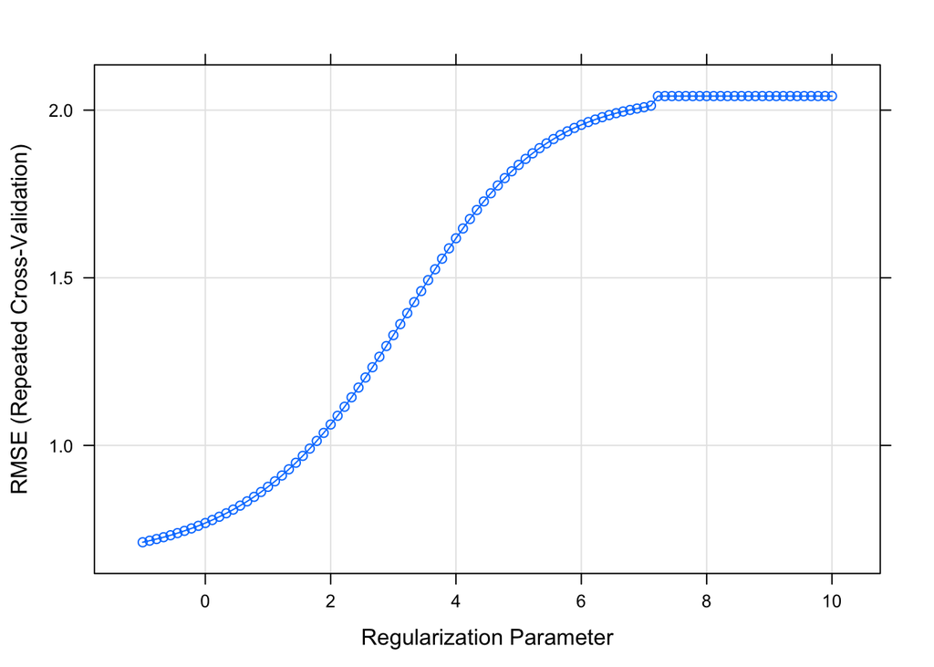

```r
plot(ridge.fit, xTrans = function(x) log(x))
```

```r
#lambda value
ridge.fit$bestTune
```

```
##   alpha    lambda
## 1     0 0.3678794
```

```r
#model coefficients
coef(ridge.fit$finalModel,ridge.fit$bestTune$lambda)
```

```
## 229 x 1 sparse Matrix of class "dgCMatrix"
##                                1
## (Intercept)        -2.7185699264
## fp001               0.0196721893
## fp002               0.0422776383
## fp003              -0.0217436843
## fp004              -0.0283370943
## fp005              -0.0177023498
## fp006              -0.0162534559
## fp007               0.0201471410
## fp008               0.0042566067
## fp009              -0.0282282520
## fp010               0.0067708705
## fp011               0.0428672012
## fp012              -0.0140285950
## fp013              -0.0299941979
## fp014              -0.0082959118
## fp015               0.0114251763
## fp016              -0.0307107386
## fp017              -0.0483570014
## fp018              -0.0302683446
## fp019               0.0199427192
## fp020               0.0272265886
## fp021              -0.0085063682
## fp022               0.0393811088
## fp023              -0.0355975637
## fp024              -0.0106876419
## fp025              -0.0050048129
## fp026               0.0400707026
## fp027               0.0487398238
## fp028               0.0215130757
## fp029              -0.0162568048
## fp030              -0.0276369931
## fp031               0.0535660180
## fp032              -0.0089594341
## fp033               0.0468420571
## fp034              -0.0426196952
## fp035              -0.0145509152
## fp036              -0.0060264009
## fp037               0.0611960622
```

[output cut: 176 more lines]

```
## num_mult_bonds     -0.1270107109
## num_rot_bonds      -0.1091932156
## num_dbl_bonds      -0.0165411581
## num_aromatic_bonds -0.0890372831
## num_hydrogen        0.0386031171
## num_carbon         -0.2146734673
## num_nitrogen        0.0855287586
## num_oxygen          0.1549543415
## num_sulfer         -0.0598392696
## num_chlorine       -0.0879008220
## num_halogen        -0.0830120370
## num_rings          -0.1072423153
## hydrophilic_factor  0.1362349200
## surface_area1       0.2483537376
## surface_area2       0.1700841040
```

```r
#test error
pred_ridge <- predict(ridge.fit, test)
mse(test$solubility, pred_ridge)
```

```
## [1] 0.545737
```

“Tuning parameter ‘alpha’ was held constant at a value of 0 RMSE was used to select the optimal model using the smallest value. The final values used for the model were alpha = 0 and lambda = 0.3678794.”

lambda = 0.3678794 test error= 0.545737

1c. Fit a lasso model on the training data, with λ chosen by cross-validation. Report the test error, along with the number of non-zero coefficient estimates.

```r
set.seed(2)
lasso.fit <- train(x, y,
                   method = "glmnet",
                   tuneGrid = expand.grid(alpha = 1,
                                          lambda = exp(seq(-1, 10, length=100))),
                   preProc = c("center", "scale"),
                   trControl = ctrl1)
lasso.fit
```

```
## glmnet
##
## 951 samples
## 228 predictors
##
## Pre-processing: centered (228), scaled (228)
## Resampling: Cross-Validated (10 fold, repeated 5 times)
## Summary of sample sizes: 855, 856, 855, 855, 856, 856, ...
## Resampling results across tuning parameters:
##
##   lambda        RMSE      Rsquared   MAE
##   3.678794e-01  1.162199  0.7656351  0.8910268
##   4.111123e-01  1.210312  0.7570369  0.9274002
##   4.594258e-01  1.267132  0.7447184  0.9708804
##   5.134171e-01  1.333258  0.7270285  1.0218166
##   5.737534e-01  1.410789  0.6993276  1.0818066
##   6.411804e-01  1.500134  0.6552076  1.1515620
##   7.165313e-01  1.592615  0.6008071  1.2234317
##   8.007374e-01  1.692289  0.5186926  1.2996607
##   8.948393e-01  1.774076  0.4494618  1.3631174
##   1.000000e+00  1.833156  0.4391675  1.4117291
##   1.117519e+00  1.899783  0.4390840  1.4681664
##   1.248849e+00  1.979810  0.4390840  1.5366397
##   1.395612e+00  2.041920        NaN  1.5903934
##   1.559623e+00  2.041920        NaN  1.5903934
##   1.742909e+00  2.041920        NaN  1.5903934
##   1.947734e+00  2.041920        NaN  1.5903934
##   2.176630e+00  2.041920        NaN  1.5903934
##   2.432425e+00  2.041920        NaN  1.5903934
##   2.718282e+00  2.041920        NaN  1.5903934
##   3.037732e+00  2.041920        NaN  1.5903934
##   3.394723e+00  2.041920        NaN  1.5903934
##   3.793668e+00  2.041920        NaN  1.5903934
##   4.239496e+00  2.041920        NaN  1.5903934
##   4.737718e+00  2.041920        NaN  1.5903934
##   5.294490e+00  2.041920        NaN  1.5903934
##   5.916694e+00  2.041920        NaN  1.5903934
##   6.612018e+00  2.041920        NaN  1.5903934
##   7.389056e+00  2.041920        NaN  1.5903934
##   8.257411e+00  2.041920        NaN  1.5903934
```

[output cut: 60 more lines]

```
##   7.250958e+03  2.041920        NaN  1.5903934
##   8.103084e+03  2.041920        NaN  1.5903934
##   9.055351e+03  2.041920        NaN  1.5903934
##   1.011953e+04  2.041920        NaN  1.5903934
##   1.130876e+04  2.041920        NaN  1.5903934
##   1.263776e+04  2.041920        NaN  1.5903934
##   1.412294e+04  2.041920        NaN  1.5903934
##   1.578265e+04  2.041920        NaN  1.5903934
##   1.763742e+04  2.041920        NaN  1.5903934
##   1.971015e+04  2.041920        NaN  1.5903934
##   2.202647e+04  2.041920        NaN  1.5903934
##
## Tuning parameter 'alpha' was held constant at a value of 1
## RMSE was used to select the optimal model using the smallest value.
## The final values used for the model were alpha = 1 and lambda = 0.3678794.
```

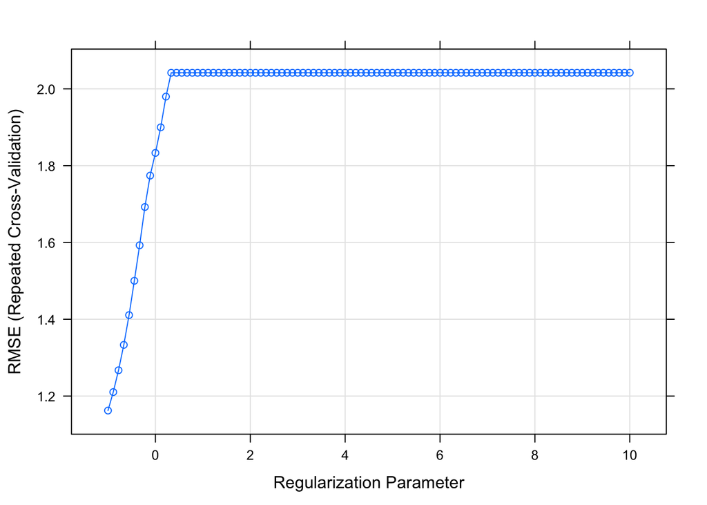

```r
plot(lasso.fit, xTrans = function(x) log(x))
```

```r
#lamda value
lasso.fit$bestTune
```

```
##   alpha    lambda
## 1     1 0.3678794
```

```r
#model coefficients
coef(lasso.fit$finalModel,lasso.fit$bestTune$lambda)
```

```
## 229 x 1 sparse Matrix of class "dgCMatrix"
##                              1
## (Intercept)        -2.71856993
## fp001               .
## fp002               .
## fp003               .
## fp004               .
## fp005               .
## fp006               .
## fp007               .
## fp008               .
## fp009               .
## fp010               .
## fp011               .
## fp012               .
## fp013               .
## fp014               .
## fp015               .
## fp016               .
## fp017               .
## fp018               .
## fp019               .
## fp020               .
## fp021               .
## fp022               .
## fp023               .
## fp024               .
## fp025               .
## fp026               .
## fp027               .
## fp028               .
## fp029               .
## fp030               .
## fp031               .
## fp032               .
## fp033               .
## fp034               .
## fp035               .
## fp036               .
## fp037               .
```

[output cut: 176 more lines]

```
## num_mult_bonds      .
## num_rot_bonds       .
## num_dbl_bonds       .
## num_aromatic_bonds  .
## num_hydrogen        .
## num_carbon         -0.27038139
## num_nitrogen        .
## num_oxygen          .
## num_sulfer          .
## num_chlorine        .
## num_halogen         .
## num_rings           .
## hydrophilic_factor  0.12616647
## surface_area1       0.40753696
## surface_area2       .
```

```r
#test error
pred_lasso <- predict(lasso.fit, test)
mse(test$solubility, pred_lasso)
```

```
## [1] 1.328538
```

lambda = 0.3678794 test error= 1.328538 #is getting the same lambda as the ridge.fit weird?

1d. Fit a principle component regression model on the training data, with M chosen by cross-validation. Report the test error, along with the value of M selected by cross-validation.

```r
ctrl1 <-trainControl(method = "repeatedcv", number = 10, repeats = 5)

set.seed(2)
pcr.fit <-train(x, y,
                method = "pcr",
                tuneGrid  =data.frame(ncomp = 1:228),
                trControl = ctrl1,
               preProc =c("center", "scale"))
pcr.fit
```

```
## Principal Component Analysis
##
## 951 samples
## 228 predictors
##
## Pre-processing: centered (228), scaled (228)
## Resampling: Cross-Validated (10 fold, repeated 5 times)
## Summary of sample sizes: 855, 856, 855, 855, 856, 856, ...
## Resampling results across tuning parameters:
##
##   ncomp  RMSE          Rsquared    MAE
##     1    2.035993e+00  0.01308784  1.575740e+00
##     2    1.971782e+00  0.07486862  1.556857e+00
##     3    1.704827e+00  0.30830677  1.347999e+00
##     4    1.601237e+00  0.38982557  1.244194e+00
```

[output cut: 227 more lines]

```r
#M value
pcr.fit$bestTune
```

```
##     ncomp
## 157   157
```

```r
#test error
pred_pcr <- predict(pcr.fit, test)
mse(test$solubility, pred_pcr)
```

```
## [1] 0.549917
```

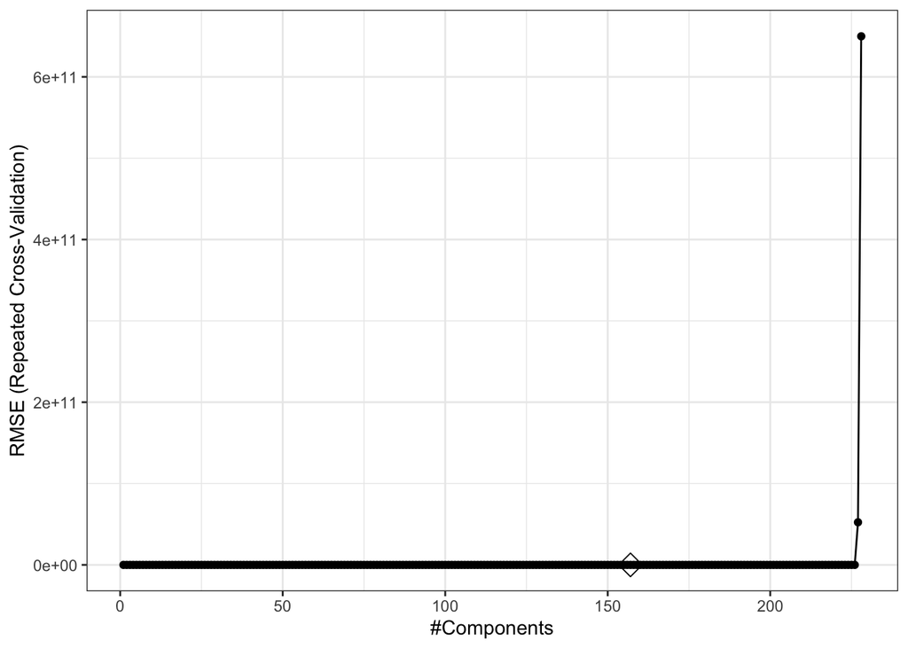

```r
ggplot(pcr.fit, highlight = TRUE) + theme_bw()
```

M = 157 MSE = 0.549917

1e. Briefly discuss the results obtained in (a)∼(d).

1f. Which model will you choose for predicting solubility?

```r
resamp <- resamples(list(lm = lmfit,
                         ridge = ridge.fit,
                         lasso = lasso.fit,
                         pcr = pcr.fit))

summary(resamp)
```

```
##
## Call:
## summary.resamples(object = resamp)
##
## Models: lm, ridge, lasso, pcr
## Number of resamples: 50
##
## MAE
##            Min.   1st Qu.    Median      Mean   3rd Qu.      Max. NA's
## lm    0.4151018 0.5042577 0.5288620 0.5304540 0.5607729 0.6838928    0
## ridge 0.4353560 0.5134338 0.5401147 0.5426589 0.5742612 0.6606337    0
## lasso 0.7358550 0.8489723 0.8805678 0.8910268 0.9388138 1.1217822    0
## pcr   0.4213811 0.5066631 0.5508642 0.5433190 0.5726849 0.6668606    0
##
## RMSE
##            Min.   1st Qu.    Median      Mean   3rd Qu.      Max. NA's
## lm    0.5763256 0.6702141 0.7006166 0.7093576 0.7470323 0.9234601    0
## ridge 0.5687731 0.6685333 0.6935677 0.7112727 0.7562382 0.8493630    0
## lasso 0.9633449 1.0965603 1.1430213 1.1621987 1.2195183 1.4401033    0
## pcr   0.5763791 0.6725372 0.7162175 0.7087392 0.7458388 0.8730497    0
##
## Rsquared
##            Min.   1st Qu.    Median      Mean   3rd Qu.      Max. NA's
## lm    0.8105782 0.8668429 0.8844072 0.8814378 0.8966132 0.9313096    0
## ridge 0.8167301 0.8701449 0.8847056 0.8806485 0.8916841 0.9210603    0
## lasso 0.6140916 0.7394218 0.7649895 0.7656351 0.7986549 0.8379632    0
## pcr   0.8131551 0.8632151 0.8848280 0.8808679 0.8975444 0.9275388    0
```

try to get to pdf!!